# Assignment 2

Hari Subhash

Date created: 2019-05-06

## Comments

1. Change author name in YAML
2. Output from `skim()` is not being displayed because you have set `results = "hide"`
3. Incorrect use of asterisk. You need to close them to get desired effect (italic, bold)
4. Avoid printing out entire vectors since their outputs will take up a lot of space (`unique(flights$arr_delay)`). Moreover, a bunch of numbers on the screen does give the reader any further insights.
5. Consider removing groups with low number of observations from consideration since they could skew your results
6. General convention - explainatory variable is on the x-axis, variable being explained on y. In our case, y - axis should be the delay variables. You have this reversed for most of your charts. Flip this around.
7. Based on your analysis there seems to be a relationship between distance and delays with shorter flights being more delayed. Why is this? Explore this further.
8. Consider cutting continous variables like distance in intervals (look at `cut_*()` set of function under ggplot)
9. Explore your explainatory variable more thoroughly before the analysis
10. Create a single dataset for weather + flights and use it for all the weather based analysis instead of creating separate ones each time.
11. Use snake_case for naming your variables.
12. Explain what is happening in each chart and your logic for trying something out. For instance, you are interested in precip vs delay because xyz.
13. Another way to look at this would be to consider extreme values of delay and see the relationship between that and the explainatory variable.
14. Consider tabsets `# {.tabset .tabset-fade .tabset-pills}`
15. Take logs when you have a skewed variable (that spans a large range) (check out `scale_x_log10()`)
16. Make things more attractive

**Due Date**: Sunday, April 28th

**Keyboard Shortcuts**:

1. Assignment operator (<-) is `Alt+-` for Windows and `Option+-` for Mac
2. Insert new code chunk `Ctrl+Alt+I` for Windows and `Command+Option+I` for Mac
3. Run a line of code `Ctrl+Enter` for Windows and `Command+Enter` for Mac
4. Run all the code within a chunk `Ctrl+Shift+Enter` for Windows and `Command+Shift+Enter` for Mac
5. Insert a pipe operator (%>%) `Ctrl+Shift+M` for Windows and `Command+Shift+M` for Mac

**General Instructions**

1. Create a new notebook (copy parts of the YAML header you are interested in keeping) to work on your assignment.
2. The assignment should be submitted via a shareable github link that points to your notebook (.nb.html) file to me on Slack.
3. Make sure the notebook is neatly formatted, and that all the charts and tables and look good when you preview it.

**Task**: Explore at least 5 different causes for departure and arrival delays (combined - not 5 each). Its not necessary that you find a definitive answer for what causes a delay, instead I want you to showcase your ability to explore the data with a combination of analytical text, tables and charts. The final output should be something you can show a prospective employer or client as proof of you ability to work with data in R.

## Let’s talk game plan

I want to try: distance, month, dest, precip, temp, visib for all of these, I may want to split by origin. My graph options include histogram, geom_point (scatter), geom_jitter, geom_smooth(method=lm), geom_line for line chart, geom_col for discrete x continuous y, geom_boxplot, geom_count and for one var, geom_hist, geom_density, geom_dotplot.

** Important notes you have never got re summarise. Group by the “background” vars you want to see compared to your dependent var. use the summarize command to perform functions on the dependent var. Don’t group by the dependent var**

*Section One First hypothesis: Distance and arrival delay, let’s see if there is a relationship. REMAINDERS: Charts A-3 and A-5 have wasted space in some of the origin facets. REMAINDERS: What we found would make it interesting to check dep_delay and Distance.

A-1: Let’s look at the data.

[output not shown]

[output cut: 212 more lines]

Nothing too obvious here. A-2: Let’s check out distance outliers.

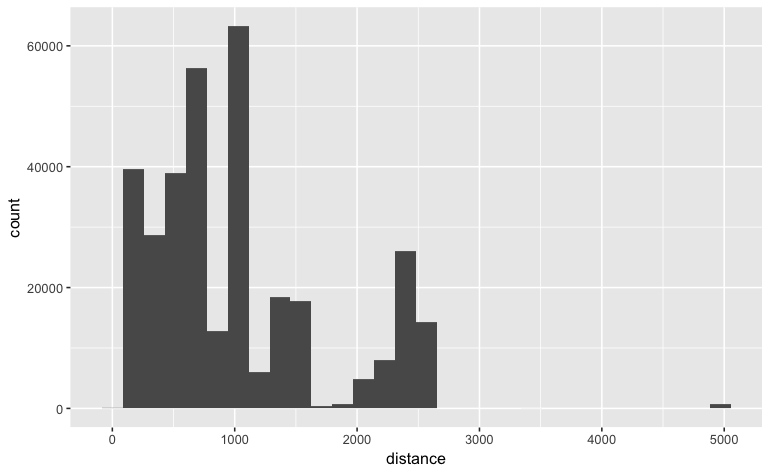

```r
flights %>%
  ggplot(aes(x = distance)) +
  geom_histogram()
```

There are some.

A-3 - Let’s facet by origin for our first major two-variable graph.

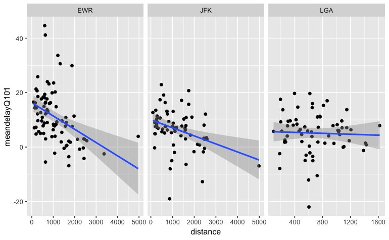

[output not shown]

[output cut: 990 more lines]

[output not shown]

[output cut: 203 more lines]

[output not shown]

[output cut: 990 more lines]

It looks like distance falls as arrival delay increases, except at LaGuardia. A little weird. The segmentation of origin I did is a bit random.

A-4: Does the relationship hold across the combined airports?

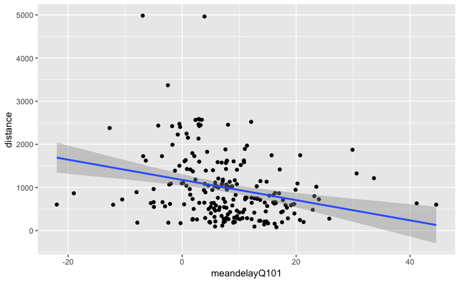

It does. A-5: Let’s try minus outlier distances.

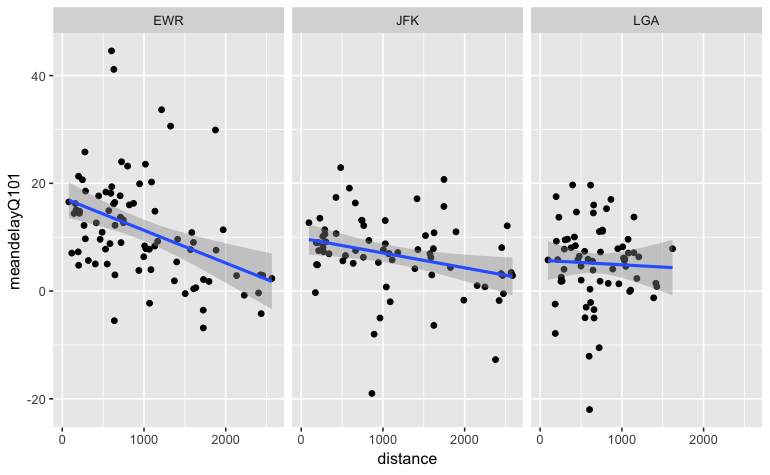

```r
flights %>%
  group_by(distance, origin) %>%
  filter(distance < 3000) %>%
  summarise(meandelayQ101 = mean(arr_delay, na.rm = T)) %>%
  arrange(distance) %>%
  ggplot(aes(x = distance, y = meandelayQ101)) +
  geom_point() +
  geom_smooth(method = lm) +
  facet_wrap(~ origin)
```

Result: still a negative relationship between distance and delay. weird. Mean delay is highest for very short flights. A-6: Let’s remove the origin faceting and check one more time.

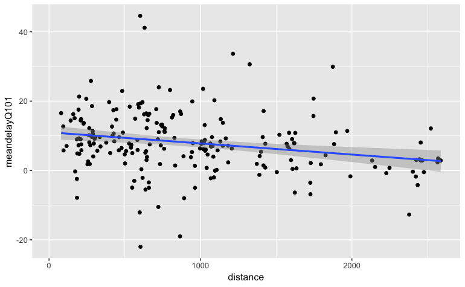

```r
flights %>%
  group_by(distance, origin) %>%
  filter(distance < 3000) %>%
  summarise(meandelayQ101 = mean(arr_delay, na.rm = T)) %>%
  arrange(distance) %>%
  ggplot(aes(x = distance, y = meandelayQ101)) +
  geom_point() +
  geom_smooth(method = lm)
```

There is a trend here.

*SECTION TWO Hypothesis Two: there is a relationship between Precip in weather and Departure Delay. (Spends a full hour understanding joins again) B-1: Let’s make our dataset. Right now, Precip and flights are separated.

```r
weather
```

```r
Preciptest <- flights %>%
  select(time_hour, origin, dep_delay) %>%
  left_join(
    x = .,
    y = weather,
    by = c("origin", "time_hour"))
```

Ok, we have a dataset. Let’s look at precip.

##Never finished this

```r
Preciptest
```

| time_hour | origin | dep_delay | year | month | day | hour | temp | dewp | humid | wind_dir | wind_speed | wind_gust | precip | pressure | visib |
| --- | --- | --- | --- | --- | --- | --- | --- | --- | --- | --- | --- | --- | --- | --- | --- |
| 2013-01-01 05:00:00 | EWR | 2 | 2013 | 1 | 1 | 5 | 39.02 | 28.04 | 64.43 | 260 | 12.65858 | NA | 0 | 1011.9 | 10 |
| 2013-01-01 05:00:00 | LGA | 4 | 2013 | 1 | 1 | 5 | 39.92 | 24.98 | 54.81 | 250 | 14.96014 | 21.86482 | 0 | 1011.4 | 10 |
| 2013-01-01 05:00:00 | JFK | 2 | 2013 | 1 | 1 | 5 | 39.02 | 26.96 | 61.63 | 260 | 14.96014 | NA | 0 | 1012.1 | 10 |
| 2013-01-01 05:00:00 | JFK | -1 | 2013 | 1 | 1 | 5 | 39.02 | 26.96 | 61.63 | 260 | 14.96014 | NA | 0 | 1012.1 | 10 |
| 2013-01-01 06:00:00 | LGA | -6 | 2013 | 1 | 1 | 6 | 39.92 | 24.98 | 54.81 | 260 | 16.11092 | 23.01560 | 0 | 1011.7 | 10 |
| 2013-01-01 05:00:00 | EWR | -4 | 2013 | 1 | 1 | 5 | 39.02 | 28.04 | 64.43 | 260 | 12.65858 | NA | 0 | 1011.9 | 10 |
| 2013-01-01 06:00:00 | EWR | -5 | 2013 | 1 | 1 | 6 | 37.94 | 28.04 | 67.21 | 240 | 11.50780 | NA | 0 | 1012.4 | 10 |
| 2013-01-01 06:00:00 | LGA | -3 | 2013 | 1 | 1 | 6 | 39.92 | 24.98 | 54.81 | 260 | 16.11092 | 23.01560 | 0 | 1011.7 | 10 |
| 2013-01-01 06:00:00 | JFK | -3 | 2013 | 1 | 1 | 6 | 37.94 | 26.96 | 64.29 | 260 | 13.80936 | NA | 0 | 1012.6 | 10 |
| 2013-01-01 06:00:00 | LGA | -2 | 2013 | 1 | 1 | 6 | 39.92 | 24.98 | 54.81 | 260 | 16.11092 | 23.01560 | 0 | 1011.7 | 10 |

[output cut: 990 more lines]

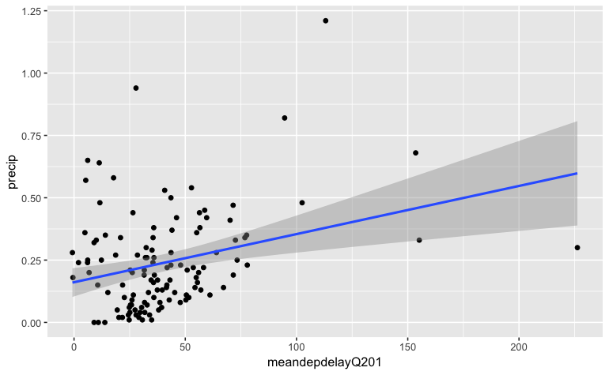

```r
Preciptest %>%
  group_by(precip, origin) %>%
  summarise(meandepdelayQ201 = mean(dep_delay, na.rm = T)) %>%
  arrange(meandepdelayQ201) %>%
  ggplot(aes(meandepdelayQ201, y = precip)) +
  geom_point() +
  geom_smooth(method = lm)
```

Looks like a bingo. Let’s wrap it by origin.

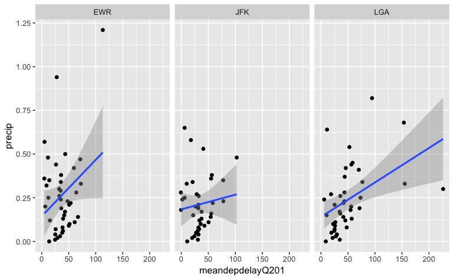

```r
Preciptest %>%
  group_by(precip, origin) %>%
  summarise(meandepdelayQ201 = mean(dep_delay, na.rm = T)) %>%
  arrange(meandepdelayQ201) %>%
  ggplot(aes(meandepdelayQ201, y = precip)) +
  geom_point() +
  geom_smooth(method = lm) +
  facet_wrap(~ origin)
```

What else can we facet wrap?

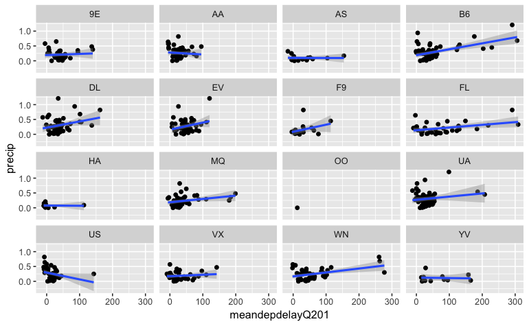

```r
Preciptest <- flights %>%
  select(time_hour, carrier, origin, dep_delay) %>%
  left_join(
    x = .,
    y = weather,
    by = c("origin", "time_hour"))

Preciptest %>%
  group_by(precip, carrier) %>%
  summarise(meandepdelayQ201 = mean(dep_delay, na.rm = T)) %>%
  arrange(meandepdelayQ201) %>%
  ggplot(aes(meandepdelayQ201, y = precip)) +
  geom_point() +
  geom_smooth(method = lm) +
  facet_wrap(~ carrier)
```

Interesting and a bit hard to parse, but the relationship certainly varies by carrier.

```r
geom_
```

SECTION THREEE ##Exploring Visib and arrival delay

##get the joins going

```r
library(tidyverse)
library(nycflights13)
DataSet4 <- flights %>%
  select(time_hour, origin, arr_delay) %>%
  left_join(weather, by = c("origin", "time_hour"))
```

##Remind myself what flights looks like.

```r
str(flights)
```

##Check our combined dataset to make sure it looks right

```r
str(DataSet4)
```

#Let’s look at Visib

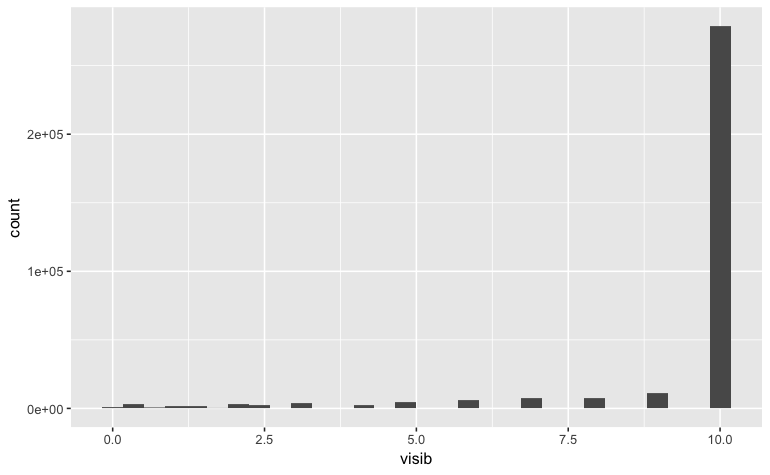

```r
DataSet4 %>%
  ggplot(aes(x = visib)) +
  geom_histogram()
```

```r
NA
```

##Hmm, looks discrete

```r
DataSet4$visib %>%
  sort() %>%
  unique()
```

```
 [1]  0.00  0.06  0.12  0.25  0.50  0.75  1.00  1.25  1.50  1.75  2.00  2.50  3.00  4.00  5.00  6.00  7.00  8.00  9.00 10.00
```

After Trial and Error, arrive at this, which is ugly and needs improvement

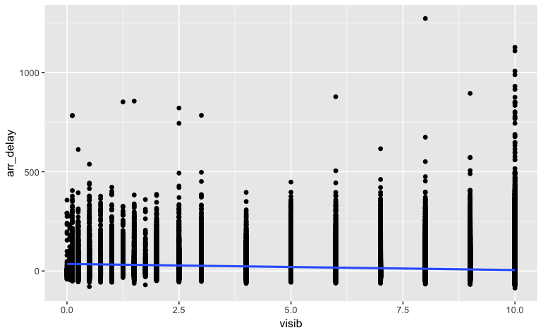

```r
DataSet4 %>%
  ggplot(aes(x = visib, y = arr_delay)) +
  geom_point() +
  geom_smooth(method = lm)
```

So the LM line appears to visually disagree with the superficial impression of the points. Are outliers affecting this? Let’s check sample sizes.

```r
DataSet4 %>%
  group_by(visib) %>%
  summarise(nObs = n())
```

```r
DataSet4 %>%
  nrow()
```

```
[1] 336776
```

Ok, let’s try something re NA purge.

```r
DataSet4 %>%
  filter(visib == visib, na.rm = T)
```

[output not shown]

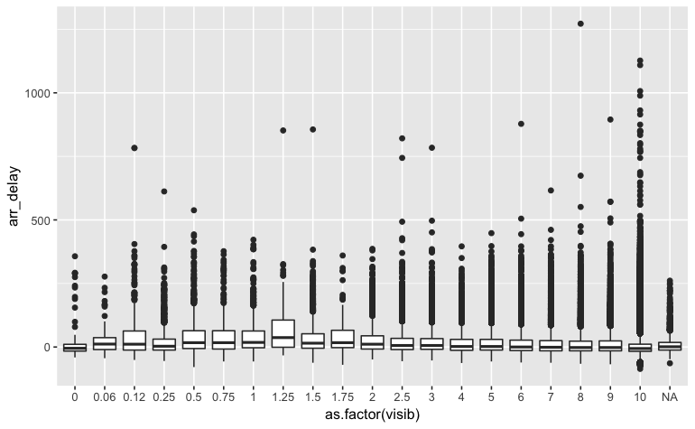

```r
DataSet4 %>%
  group_by(visib) %>%
ggplot(aes(x = as.factor(visib), y = arr_delay), na.rm = T ) +
  geom_boxplot()
```

Okay, this kinda works! You could sort of read a trend into this, but it seems to decline around “1”

```r
 DataSet4 <- DataSet4 %>%
  filter(visib > 0.11)

DataSet4 %>%
  ggplot(aes(x = visib, y = arr_delay)) +
  geom_point() +
  geom_smooth(method = lm)
```

[output not shown]